# Data 502 Midterm

Travis McKenzie

2023-10-06

# Load the Tidyverse, Import Data & Run Summary

Loading my tidyverse library, importing my data and utilizing a summary to conduct a quick analysis of the available information.

```r
library(tidyverse)
fast <- read.csv("https://raw.githubusercontent.com/kitadasmalley/Teaching/main/DATA502/FA2023/Data/fastFood2022.csv")
summary(fast)
```

```
##       rank         company            category         systemwide_sales
##  Min.   : 1.00   Length:50          Length:50          Min.   :  685
##  1st Qu.:13.25   Class :character   Class :character   1st Qu.: 1013
##  Median :25.50   Mode  :character   Mode  :character   Median : 2531
##  Mean   :25.50                                         Mean   : 5349
##  3rd Qu.:37.75                                         3rd Qu.: 5412
##  Max.   :50.00                                         Max.   :48734
##  avg_sales_per_thousand franchised_licensed_units company_units
##  Min.   : 300           Min.   :    0             Min.   :   0.0
##  1st Qu.:1161           1st Qu.:  495             1st Qu.:  33.5
##  Median :1612           Median : 1152             Median : 173.0
##  Mean   :1904           Mean   : 2694             Mean   : 515.4
##  3rd Qu.:2097           3rd Qu.: 3142             3rd Qu.: 401.2
##  Max.   :6710           Max.   :20576             Max.   :9265.0
##   total_units       change_units
##  Min.   :  287.0   Min.   :-571.0
##  1st Qu.:  792.5   1st Qu.: -10.5
##  Median : 1714.0   Median :  21.5
##  Mean   : 3209.5   Mean   :  44.8
##  3rd Qu.: 3513.2   3rd Qu.:  85.0
##  Max.   :20576.0   Max.   : 429.0
```

## Change Units and Assess Values to identify Variables for plotting

Updating units to represent as Millions. Running some code to confirm which metrics I am using on my X and Y axis. Also referencing my summary above to confirm some of this information. Confirming that I want total_units as my X and avg_sales_per_mil as my Y. Will be mapping size to systemwide_sales. edit: ended up coming back to the set-up. Tropical Smoothie Cafe was giving me grief when attempting to use company in my recreation graph.

```r
fast<-fast%>%
mutate(avg_sales_per_mil=avg_sales_per_thousand/1000)

names(fast)
```

```
##  [1] "rank"                      "company"
##  [3] "category"                  "systemwide_sales"
##  [5] "avg_sales_per_thousand"    "franchised_licensed_units"
##  [7] "company_units"             "total_units"
##  [9] "change_units"              "avg_sales_per_mil"
```

```r
fast[which.max(fast$total_units),]
```

|  | rank | company | category | systemwide_sales | avg_sales_per_thousand | franchised_licensed_units | company_units | total_units | change_units | avg_sales_per_mil |
| --- | --- | --- | --- | --- | --- | --- | --- | --- | --- | --- |
| 7 | 7 | Subway* | Sandwich | 10372 | 510 | 20576 | 0 | 20576 | -571 | 0.51 |

```r
fast[which.max(fast$avg_sales_per_mil),]
```

|  | rank | company | category | systemwide_sales | avg_sales_per_thousand | franchised_licensed_units | company_units | total_units | change_units | avg_sales_per_mil |
| --- | --- | --- | --- | --- | --- | --- | --- | --- | --- | --- |
| 3 | 3 | Chick-fil-A* | Chicken | 18814 | 6710 | 2764 | 73 | 2837 | 153 | 6.71 |

```r
fast[which.max(fast$systemwide_sales),]
```

|  | rank | company | category | systemwide_sales | avg_sales_per_thousand | franchised_licensed_units | company_units | total_units | change_units | avg_sales_per_mil |
| --- | --- | --- | --- | --- | --- | --- | --- | --- | --- | --- |
| 1 | 1 | McDonald's | Burger | 48734 | 3625 | 12751 | 693 | 13444 | 6 | 3.625 |

```r
mcd=fast %>%
  filter(company=="McDonald's")

unique(fast$company)
```

```
##  [1] "McDonald's"
##  [2] "Starbucks*"
##  [3] "Chick-fil-A*"
##  [4] "Taco Bell"
##  [5] "Wendy's"
##  [6] "Dunkin'"
##  [7] "Subway*"
##  [8] "Burger King"
##  [9] "Domino's"
## [10] "Chipotle"
## [11] "Panera Bread*"
## [12] "Pizza Hut"
## [13] "Sonic Drive-In"
## [14] "Panda Express"
## [15] "KFC"
```

[output cut: 35 more lines]

```r
fast[36,]
```

|  | rank | company | category | systemwide_sales | avg_sales_per_thousand | franchised_licensed_units | company_units | total_units | change_units | avg_sales_per_mil |
| --- | --- | --- | --- | --- | --- | --- | --- | --- | --- | --- |
| 36 | 36 | Tropical Smoothie Caf\x8e | Snack | 1075 | 993 | 1197 | 1 | 1198 | 159 | 0.993 |

```r
fast=fast%>%
  mutate(company=str_replace(company, "�", "e"))

head(fast, 50)
```

|  | rank | company | category | systemwide_sales | avg_sales_per_thousand | franchised_licensed_units | company_units | total_units | change_units | avg_sales_per_mil |
| --- | --- | --- | --- | --- | --- | --- | --- | --- | --- | --- |
| 1 | 1 | McDonald's | Burger | 48734 | 3625 | 12751 | 693 | 13444 | 6 | 3.625 |
| 2 | 2 | Starbucks* | Snack | 28100 | 1680 | 6608 | 9265 | 15873 | 429 | 1.680 |
| 3 | 3 | Chick-fil-A* | Chicken | 18814 | 6710 | 2764 | 73 | 2837 | 153 | 6.710 |
| 4 | 4 | Taco Bell | Global | 13850 | 1900 | 6734 | 464 | 7198 | 196 | 1.900 |
| 5 | 5 | Wendy's | Burger | 11694 | 1973 | 5591 | 403 | 5994 | 56 | 1.973 |
| 6 | 6 | Dunkin' | Snack | 11279 | 1200 | 9339 | 31 | 9370 | 126 | 1.200 |
| 7 | 7 | Subway* | Sandwich | 10372 | 510 | 20576 | 0 | 20576 | -571 | 0.510 |
| 8 | 8 | Burger King | Burger | 10278 | 1508 | 6993 | 50 | 7043 | -61 | 1.508 |
| 9 | 9 | Domino's | Pizza | 8752 | 1309 | 6400 | 286 | 6686 | 126 | 1.309 |
| 10 | 10 | Chipotle | Global | 8600 | 2800 | 0 | 3129 | 3129 | 211 | 2.800 |

[output cut: 40 more lines]

##Construct my recreation graph This took a lot longer than I had hoped it would and ended up getting stuck several times. The initial phase of establishing the plots and getting the basic look was quick. Once I started getting into the details, things slowed dramatically and became a tad tedious and frustrating. Doing some of the Datacamp modules again, along with the repeating some of the optional exercises to hopefully identify some skill gaps.

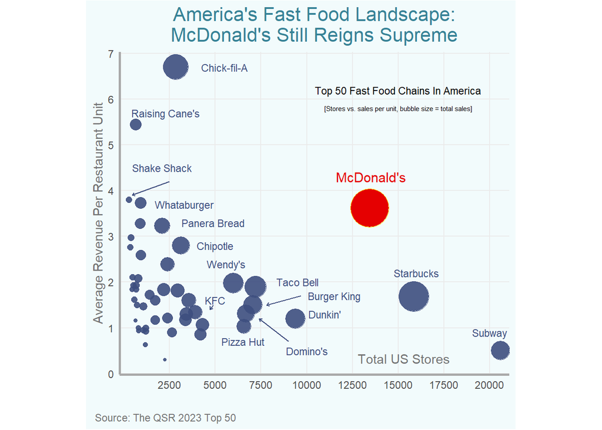

```r
ggplot(fast, aes(total_units, avg_sales_per_mil))+
  geom_point(alpha=.9, color="#3d4e7f",aes(size=systemwide_sales))+
  geom_point(data=mcd, size=15, fill="#e50001", color="yellow", pch=21)+
  scale_size(range=c(1,15))+
  ggtitle("America's Fast Food Landscape:
McDonald's Still Reigns Supreme")+
  coord_fixed(ratio=2500)+
  scale_x_continuous(expand=c(0,500),breaks=seq(2500,25000, by=2500))+
  scale_y_continuous(breaks=seq(0,7, by=1))+
  labs(y="Average Revenue Per Restaurant Unit", x="Total US Stores", caption="Source: The QSR 2023 Top 50")+
  annotate("text", x=13500, y=4.3, label="McDonald's", color="#e50001", size=4)+
  annotate("text", x=5500, y=6.7, label="Chick-fil-A", color="#3d4e7f", size=3)+
  annotate("text", x=2300, y=5.7, label="Raising Cane's", color="#3d4e7f", size=3)+
  annotate("text", x=2100, y=4.5, label="Shake Shack", color="#3d4e7f", size=3)+
  annotate("segment", x=2500, y=4.2, xend=450, yend=3.9,color="#3d4e7f", arrow=arrow(length=unit(1,"mm")))+
  annotate("text", x=3300, y=3.7, label="Whataburger", color="#3d4e7f", size=3)+
  annotate("text", x=4900, y=3.3, label="Panera Bread", color="#3d4e7f", size=3)+
  annotate("text", x=5000, y=2.8, label="Chipotle", color="#3d4e7f", size=3)+
  annotate("text", x=5600, y=2.4, label="Wendy's", color="#3d4e7f", size=3)+
  annotate("text", x=5000, y=1.6, label="KFC", color="#3d4e7f", size=3)+
  annotate("segment", x=4900, y=1.5, xend=4700, yend=1.4,color="#3d4e7f", arrow=arrow(length=unit(1,"mm")))+
  annotate("text", x=9500, y=2, label="Taco Bell", color="#3d4e7f", size=3)+
  annotate("text", x=11500, y=1.7, label="Burger King", color="#3d4e7f", size=3)+
  annotate("segment", x=9700, y=1.7, xend=7800, yend=1.5,color="#3d4e7f", arrow=arrow(length=unit(1,"mm")))+
  annotate("text", x=11000, y=1.3, label="Dunkin'", color="#3d4e7f", size=3)+
  annotate("text", x=6500, y=.7, label="Pizza Hut", color="#3d4e7f", size=3)+
  annotate("text", x=10000, y=.5, label="Domino's", color="#3d4e7f", size=3)+
  annotate("segment", x=9000, y=.7, xend=7400, yend=1.2,color="#3d4e7f", arrow=arrow(length=unit(1,"mm")))+
  annotate("text", x=16000, y=2.2, label="Starbucks", color="#3d4e7f", size=3)+
  annotate("text", x=20000, y=.9, label="Subway", color="#3d4e7f", size=3)+
  annotate("text", x=15000, y=6.2, label="Top 50 Fast Food Chains In America", size=3)+
  annotate("text", x=15000, y=5.8, label="[Stores vs. sales per unit, bubble size = total sales]", size=2)+
  theme(
    panel.grid = element_blank(),
    panel.background = element_rect(fill="#f2fbfc"),
    panel.grid.major.x = element_line(color="gray92"),
    panel.grid.major.y = element_line(color="gray92"),
    axis.line=element_line(color="darkgray", size=1),
    axis.ticks=element_blank(),
    axis.title.x.bottom = element_text(vjust=16, hjust=.8,color="#727373"),
    axis.title.y.left = element_text(color="#727373"),
    legend.position="none",
    plot.background = element_rect(fill="#f2fbfc"),
    plot.title=element_text(hjust=.5,size=16, color="#378296"),
    plot.caption = element_text(hjust=-0.1, color="#727373")
  )
```

##Comments on the Recreation I could not figure out how to change the McDonald’s bubble and got frustrated and had to concede that adjustment. The techniques I was trying kept breaking the graph. Overall I am satisfied with a deeper understanding of leveraging the labels, annotations, themes and formatting. It isn’t perfect, but I think I got pretty close. edit: WOOOOOO I GOT IT!!! Wednesday night!!! Dug back through the examples and was able to layer it on top. It may not be perfect, but I freaking got it! Heck, my solve even got me over the hump related to the yellow ring! Wahoo!

#Creating an Alternative: A critique of the original In recreating the original graph, I found the over-labeling a cumbersome (of course in re-reading the instructions, I only needed to do 5 (insert=Homer”doh”). I found it was really only necessary due to the type of the plot. I found the original graphic overbroad. As a refined American, I obviously felt compelled to focus in on “Burgers” and remove some of the clutter from my plot.

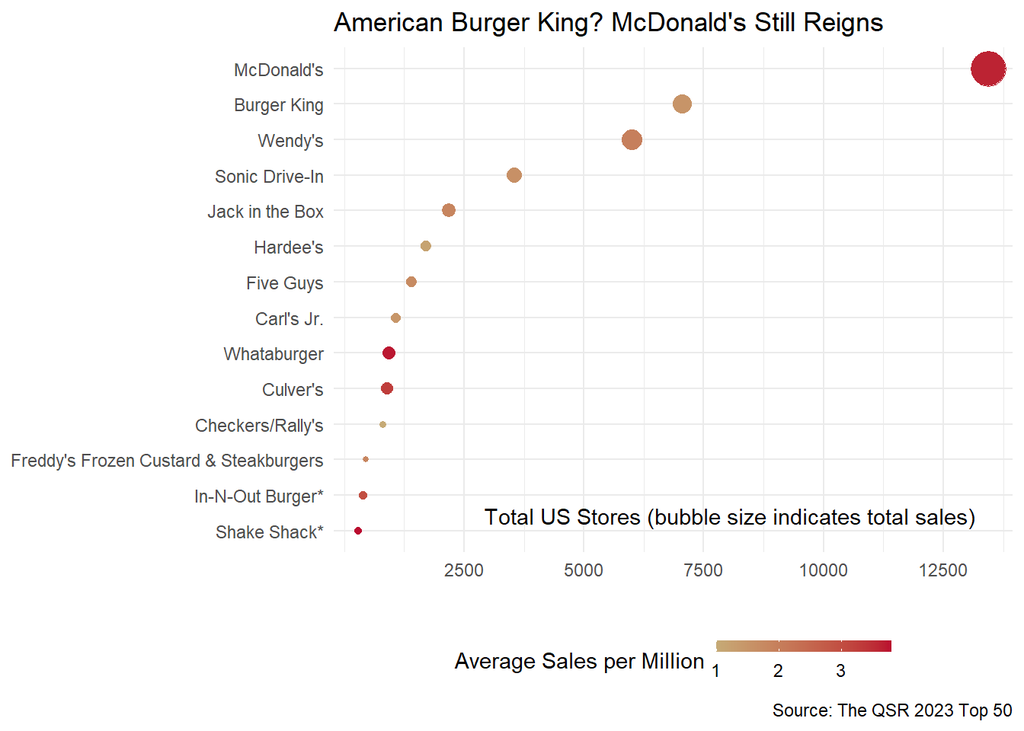

```r
fast %>%
  filter(category=="Burger")%>%
  ggplot(aes(total_units, reorder(company, total_units),color=avg_sales_per_mil))+
  geom_point(aes(size=systemwide_sales))+
  scale_size(range=c(1,8), guide="none")+
  scale_color_continuous(low="#C6AA76", high="#BA0C2F", name="Average Sales per Million")+
  scale_x_continuous(expand=c(0,500),breaks=seq(2500,25000, by=2500))+
  ggtitle("American Burger King? McDonald's Still Reigns")+
  labs(x="Total US Stores (bubble size indicates total sales)", caption="Source: The QSR 2023 Top 50")+
  theme_minimal()+
  theme(
    axis.ticks=element_blank(),
    axis.title.y = element_blank(),
    legend.position = "bottom",
    legend.key.height=unit(.2, 'cm'),
    axis.title.x.bottom = element_text(vjust=18, hjust=.8)
  )
```

#Conclusion I really got on a role once I was able to troubleshoot some issues. The formatting of Tropical Smoothie Cafe slowed me down until I went back through some notes and was able to correct the data. Ultimately, there is more I wanted to do with my recreation, but I ran out of time. I took inspiration from the Di Cook video when I thought through how I wanted to re-imagine the information. This got me thinking about running a function and loop (which we just learned in Dr. Gore’s class the other day) to run and create multiple graphs by category. I focused on burgers so I could seize the opportunity to leverage a punny title. Also, when it comes to fast food, secretly everyone initially thinks of burgers. I am pretty happy with it aside from some other non-data ink adjustments that I would have made with more time to play. I really enjoyed this process after I got past some stages of frustration and feeling stuck. I think the more I practice with this, the more I will grow to enjoy it. I feel much more in command of ggplot now than I did when I started this assignment.